# Risk Factor Analysis

## Outcome Variable

**Outcome Variable:** swasted

## Predictor Variables

**Intervention Variable:** gagebrth

**Adjustment Set:**

- arm
- sex
- W_mage
- meducyrs
- feducyrs
- hhwealth_quart
- W_nrooms
- W_nchldlt5
- brthmon
- W_parity
- impfloor
- impsan
- safeh20
- delta_W_mage
- delta_meducyrs
- delta_feducyrs
- delta_hhwealth_quart
- delta_W_nrooms
- delta_W_nchldlt5
- delta_brthmon
- delta_W_parity
- delta_impfloor
- delta_impsan
- delta_safeh20

## Stratifying Variables

The analysis was stratified on these variable(s):

- agecat
- studyid
- country

## Data Summary

| agecat | studyid | country | gagebrth | swasted | n_cell | n |
| --- | --- | --- | --- | --- | --- | --- |
| Birth | ki1000108-CMC-V-BCS-2002 | INDIA | Full or late term | 0 | 51 | 87 |
| Birth | ki1000108-CMC-V-BCS-2002 | INDIA | Full or late term | 1 | 3 | 87 |
| Birth | ki1000108-CMC-V-BCS-2002 | INDIA | Preterm | 0 | 10 | 87 |
| Birth | ki1000108-CMC-V-BCS-2002 | INDIA | Preterm | 1 | 0 | 87 |
| Birth | ki1000108-CMC-V-BCS-2002 | INDIA | Early term | 0 | 22 | 87 |
| Birth | ki1000108-CMC-V-BCS-2002 | INDIA | Early term | 1 | 1 | 87 |
| Birth | ki1000108-IRC | INDIA | Full or late term | 0 | 187 | 328 |
| Birth | ki1000108-IRC | INDIA | Full or late term | 1 | 26 | 328 |
| Birth | ki1000108-IRC | INDIA | Preterm | 0 | 22 | 328 |
| Birth | ki1000108-IRC | INDIA | Preterm | 1 | 10 | 328 |
| Birth | ki1000108-IRC | INDIA | Early term | 0 | 67 | 328 |
| Birth | ki1000108-IRC | INDIA | Early term | 1 | 16 | 328 |
| Birth | ki1000109-EE | PAKISTAN | Full or late term | 0 | 0 | 2 |
| Birth | ki1000109-EE | PAKISTAN | Full or late term | 1 | 0 | 2 |
| Birth | ki1000109-EE | PAKISTAN | Preterm | 0 | 2 | 2 |
| Birth | ki1000109-EE | PAKISTAN | Preterm | 1 | 0 | 2 |
| Birth | ki1000109-EE | PAKISTAN | Early term | 0 | 0 | 2 |
| Birth | ki1000109-EE | PAKISTAN | Early term | 1 | 0 | 2 |
| Birth | ki1000304b-SAS-CompFeed | INDIA | Full or late term | 0 | 1 | 166 |
| Birth | ki1000304b-SAS-CompFeed | INDIA | Full or late term | 1 | 0 | 166 |
| Birth | ki1000304b-SAS-CompFeed | INDIA | Preterm | 0 | 147 | 166 |
| Birth | ki1000304b-SAS-CompFeed | INDIA | Preterm | 1 | 4 | 166 |
| Birth | ki1000304b-SAS-CompFeed | INDIA | Early term | 0 | 13 | 166 |
| Birth | ki1000304b-SAS-CompFeed | INDIA | Early term | 1 | 1 | 166 |
| Birth | ki1017093c-NIH-Crypto | BANGLADESH | Full or late term | 0 | 6 | 23 |
| Birth | ki1017093c-NIH-Crypto | BANGLADESH | Full or late term | 1 | 0 | 23 |
| Birth | ki1017093c-NIH-Crypto | BANGLADESH | Preterm | 0 | 3 | 23 |
| Birth | ki1017093c-NIH-Crypto | BANGLADESH | Preterm | 1 | 0 | 23 |
| Birth | ki1017093c-NIH-Crypto | BANGLADESH | Early term | 0 | 13 | 23 |
| Birth | ki1017093c-NIH-Crypto | BANGLADESH | Early term | 1 | 1 | 23 |

[output cut: 168 more lines]

The following strata were considered:

- agecat: 24 months, studyid: ki1000108-CMC-V-BCS-2002, country: INDIA
- agecat: 24 months, studyid: ki1000108-IRC, country: INDIA
- agecat: 24 months, studyid: ki1017093c-NIH-Crypto, country: BANGLADESH
- agecat: 24 months, studyid: ki1066203-TanzaniaChild2, country: TANZANIA, UNITED REPUBLIC OF
- agecat: 24 months, studyid: ki1101329-Keneba, country: GAMBIA
- agecat: 24 months, studyid: ki1119695-PROBIT, country: BELARUS
- agecat: 24 months, studyid: ki1135781-COHORTS, country: GUATEMALA
- agecat: 24 months, studyid: ki1135781-COHORTS, country: INDIA
- agecat: 24 months, studyid: ki1135781-COHORTS, country: PHILIPPINES
- agecat: 24 months, studyid: kiGH5241-JiVitA-3, country: BANGLADESH
- agecat: 6 months, studyid: ki1000108-CMC-V-BCS-2002, country: INDIA
- agecat: 6 months, studyid: ki1000108-IRC, country: INDIA
- agecat: 6 months, studyid: ki1000109-EE, country: PAKISTAN
- agecat: 6 months, studyid: ki1000304b-SAS-CompFeed, country: INDIA
- agecat: 6 months, studyid: ki1017093c-NIH-Crypto, country: BANGLADESH
- agecat: 6 months, studyid: ki1066203-TanzaniaChild2, country: TANZANIA, UNITED REPUBLIC OF
- agecat: 6 months, studyid: ki1101329-Keneba, country: GAMBIA
- agecat: 6 months, studyid: ki1119695-PROBIT, country: BELARUS
- agecat: 6 months, studyid: ki1135781-COHORTS, country: GUATEMALA
- agecat: 6 months, studyid: ki1135781-COHORTS, country: INDIA
- agecat: 6 months, studyid: ki1135781-COHORTS, country: PHILIPPINES
- agecat: 6 months, studyid: kiGH5241-JiVitA-3, country: BANGLADESH
- agecat: Birth, studyid: ki1000108-CMC-V-BCS-2002, country: INDIA
- agecat: Birth, studyid: ki1000108-IRC, country: INDIA
- agecat: Birth, studyid: ki1000109-EE, country: PAKISTAN
- agecat: Birth, studyid: ki1000304b-SAS-CompFeed, country: INDIA
- agecat: Birth, studyid: ki1017093c-NIH-Crypto, country: BANGLADESH
- agecat: Birth, studyid: ki1101329-Keneba, country: GAMBIA
- agecat: Birth, studyid: ki1119695-PROBIT, country: BELARUS
- agecat: Birth, studyid: ki1135781-COHORTS, country: GUATEMALA
- agecat: Birth, studyid: ki1135781-COHORTS, country: INDIA
- agecat: Birth, studyid: ki1135781-COHORTS, country: PHILIPPINES
- agecat: Birth, studyid: kiGH5241-JiVitA-3, country: BANGLADESH

### Dropped Strata

Some strata were dropped due to rare outcomes:

- agecat: Birth, studyid: ki1000108-CMC-V-BCS-2002, country: INDIA
- agecat: Birth, studyid: ki1000109-EE, country: PAKISTAN
- agecat: Birth, studyid: ki1000304b-SAS-CompFeed, country: INDIA
- agecat: Birth, studyid: ki1017093c-NIH-Crypto, country: BANGLADESH
- agecat: Birth, studyid: ki1101329-Keneba, country: GAMBIA
- agecat: 6 months, studyid: ki1000108-CMC-V-BCS-2002, country: INDIA
- agecat: 6 months, studyid: ki1000109-EE, country: PAKISTAN
- agecat: 6 months, studyid: ki1000304b-SAS-CompFeed, country: INDIA
- agecat: 6 months, studyid: ki1017093c-NIH-Crypto, country: BANGLADESH
- agecat: 6 months, studyid: ki1066203-TanzaniaChild2, country: TANZANIA, UNITED REPUBLIC OF
- agecat: 6 months, studyid: ki1101329-Keneba, country: GAMBIA
- agecat: 6 months, studyid: ki1119695-PROBIT, country: BELARUS
- agecat: 6 months, studyid: ki1135781-COHORTS, country: GUATEMALA
- agecat: 24 months, studyid: ki1000108-CMC-V-BCS-2002, country: INDIA
- agecat: 24 months, studyid: ki1000108-IRC, country: INDIA
- agecat: 24 months, studyid: ki1017093c-NIH-Crypto, country: BANGLADESH
- agecat: 24 months, studyid: ki1066203-TanzaniaChild2, country: TANZANIA, UNITED REPUBLIC OF
- agecat: 24 months, studyid: ki1101329-Keneba, country: GAMBIA
- agecat: 24 months, studyid: ki1119695-PROBIT, country: BELARUS
- agecat: 24 months, studyid: ki1135781-COHORTS, country: GUATEMALA
- agecat: 24 months, studyid: ki1135781-COHORTS, country: INDIA

## Methods Detail

We’re interested in the causal parameters $E[Y_a]$ for all values of $a \in \mathcal{A}$. These parameters represent the mean outcome if, possibly contrary to fact, we intervened to set all units to have $A=a$. Under the randomization and positivity assumptions, these are identified by the statistical parameters $\psi_a=E_W[E_{Y|A,W}(Y|A=a,W)]$. In addition, we’re interested in the mean of $Y$, $E[Y]$ under no intervention (the observed mean). We will estimate these parameters by using SuperLearner to fit the relevant likelihood factors – $E_{Y|A,W}(Y|A=a,W)$ and $p(A=a|W)$, and then updating our likelihood fit using a joint TMLE.

For unadjusted analyses ($W=\{\}$), initial likelihoods were estimated using Lrnr_glm to estimate the simple $E(Y|A)$ and Lrnr_mean to estimate $p(A)$. For adjusted analyses, a small library containing Lrnr_glmnet, Lrnr_xgboost, and Lrnr_mean was used.

Having estimated these parameters, we will then use the delta method to estimate relative risks and attributable risks relative to a prespecified baseline level of $A$.

# Results Detail

## Results Plots

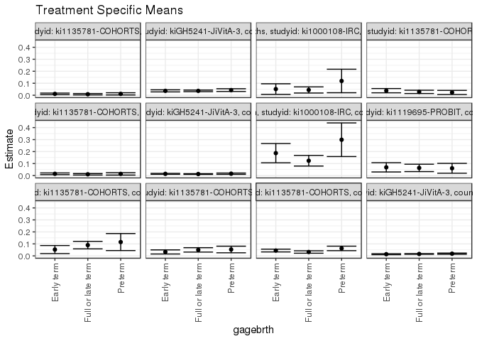

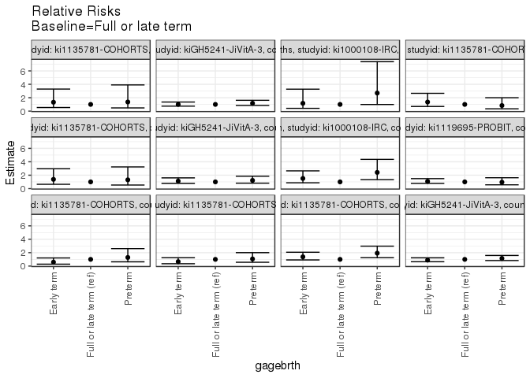

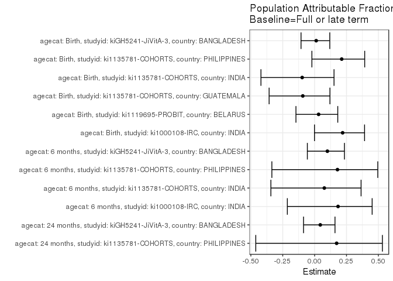

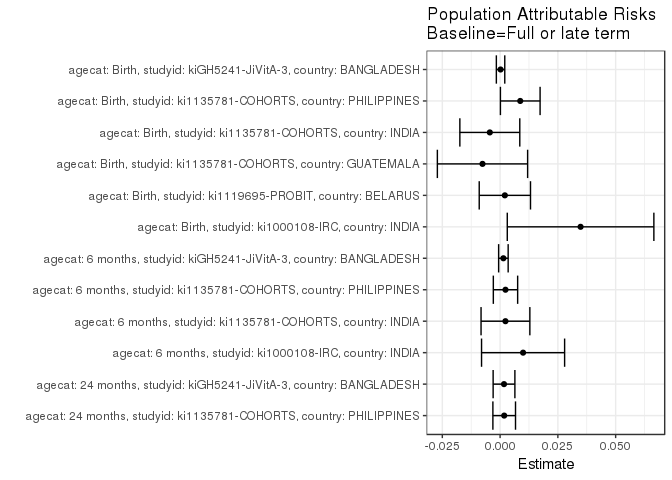

## Results Table

### Parameter: TSM

| agecat | studyid | country | intervention_level | baseline_level | estimate | ci_lower | ci_upper |
| --- | --- | --- | --- | --- | --- | --- | --- |
| Birth | ki1000108-IRC | INDIA | Full or late term | NA | 0.1237117 | 0.0793249 | 0.1680985 |
| Birth | ki1000108-IRC | INDIA | Preterm | NA | 0.2987355 | 0.1585726 | 0.4388984 |
| Birth | ki1000108-IRC | INDIA | Early term | NA | 0.1870672 | 0.1068764 | 0.2672580 |
| Birth | ki1119695-PROBIT | BELARUS | Full or late term | NA | 0.0638359 | 0.0330810 | 0.0945908 |
| Birth | ki1119695-PROBIT | BELARUS | Preterm | NA | 0.0608241 | 0.0194882 | 0.1021599 |
| Birth | ki1119695-PROBIT | BELARUS | Early term | NA | 0.0687118 | 0.0299498 | 0.1074737 |
| Birth | ki1135781-COHORTS | GUATEMALA | Full or late term | NA | 0.0897833 | 0.0585802 | 0.1209863 |
| Birth | ki1135781-COHORTS | GUATEMALA | Preterm | NA | 0.1153846 | 0.0444216 | 0.1863476 |
| Birth | ki1135781-COHORTS | GUATEMALA | Early term | NA | 0.0526316 | 0.0191341 | 0.0861291 |
| Birth | ki1135781-COHORTS | INDIA | Full or late term | NA | 0.0500107 | 0.0317980 | 0.0682234 |
| Birth | ki1135781-COHORTS | INDIA | Preterm | NA | 0.0532938 | 0.0257677 | 0.0808199 |
| Birth | ki1135781-COHORTS | INDIA | Early term | NA | 0.0328543 | 0.0156675 | 0.0500412 |
| Birth | ki1135781-COHORTS | PHILIPPINES | Full or late term | NA | 0.0323353 | 0.0222911 | 0.0423796 |
| Birth | ki1135781-COHORTS | PHILIPPINES | Preterm | NA | 0.0622460 | 0.0433889 | 0.0811032 |
| Birth | ki1135781-COHORTS | PHILIPPINES | Early term | NA | 0.0444736 | 0.0327973 | 0.0561500 |
| Birth | kiGH5241-JiVitA-3 | BANGLADESH | Full or late term | NA | 0.0159835 | 0.0129943 | 0.0189727 |
| Birth | kiGH5241-JiVitA-3 | BANGLADESH | Preterm | NA | 0.0182663 | 0.0133634 | 0.0231692 |
| Birth | kiGH5241-JiVitA-3 | BANGLADESH | Early term | NA | 0.0142192 | 0.0100881 | 0.0183503 |
| 6 months | ki1000108-IRC | INDIA | Full or late term | NA | 0.0441767 | 0.0186206 | 0.0697328 |
| 6 months | ki1000108-IRC | INDIA | Preterm | NA | 0.1190476 | 0.0209812 | 0.2171141 |
| 6 months | ki1000108-IRC | INDIA | Early term | NA | 0.0515464 | 0.0074879 | 0.0956049 |
| 6 months | ki1135781-COHORTS | INDIA | Full or late term | NA | 0.0281690 | 0.0145571 | 0.0417810 |
| 6 months | ki1135781-COHORTS | INDIA | Preterm | NA | 0.0234114 | 0.0062660 | 0.0405568 |
| 6 months | ki1135781-COHORTS | INDIA | Early term | NA | 0.0382022 | 0.0203858 | 0.0560186 |
| 6 months | ki1135781-COHORTS | PHILIPPINES | Full or late term | NA | 0.0107004 | 0.0044097 | 0.0169910 |
| 6 months | ki1135781-COHORTS | PHILIPPINES | Preterm | NA | 0.0139860 | 0.0043606 | 0.0236114 |
| 6 months | ki1135781-COHORTS | PHILIPPINES | Early term | NA | 0.0147465 | 0.0075730 | 0.0219201 |
| 6 months | kiGH5241-JiVitA-3 | BANGLADESH | Full or late term | NA | 0.0128519 | 0.0097354 | 0.0159683 |
| 6 months | kiGH5241-JiVitA-3 | BANGLADESH | Preterm | NA | 0.0157293 | 0.0102497 | 0.0212090 |
| 6 months | kiGH5241-JiVitA-3 | BANGLADESH | Early term | NA | 0.0144058 | 0.0104781 | 0.0183334 |
| 24 months | ki1135781-COHORTS | PHILIPPINES | Full or late term | NA | 0.0085197 | 0.0026400 | 0.0143995 |
| 24 months | ki1135781-COHORTS | PHILIPPINES | Preterm | NA | 0.0116054 | 0.0023715 | 0.0208394 |
| 24 months | ki1135781-COHORTS | PHILIPPINES | Early term | NA | 0.0113169 | 0.0046657 | 0.0179680 |
| 24 months | kiGH5241-JiVitA-3 | BANGLADESH | Full or late term | NA | 0.0364900 | 0.0299130 | 0.0430669 |
| 24 months | kiGH5241-JiVitA-3 | BANGLADESH | Preterm | NA | 0.0428266 | 0.0315395 | 0.0541136 |
| 24 months | kiGH5241-JiVitA-3 | BANGLADESH | Early term | NA | 0.0365481 | 0.0277652 | 0.0453310 |

### Parameter: E(Y)

| agecat | studyid | country | intervention_level | baseline_level | estimate | ci_lower | ci_upper |
| --- | --- | --- | --- | --- | --- | --- | --- |
| Birth | ki1000108-IRC | INDIA | NA | NA | 0.1585366 | 0.1189492 | 0.1981239 |
| Birth | ki1119695-PROBIT | BELARUS | NA | NA | 0.0658999 | 0.0328405 | 0.0989593 |
| Birth | ki1135781-COHORTS | GUATEMALA | NA | NA | 0.0821678 | 0.0596429 | 0.1046927 |
| Birth | ki1135781-COHORTS | INDIA | NA | NA | 0.0455655 | 0.0339017 | 0.0572293 |
| Birth | ki1135781-COHORTS | PHILIPPINES | NA | NA | 0.0410578 | 0.0338021 | 0.0483134 |
| Birth | kiGH5241-JiVitA-3 | BANGLADESH | NA | NA | 0.0161856 | 0.0137999 | 0.0185712 |
| 6 months | ki1000108-IRC | INDIA | NA | NA | 0.0541237 | 0.0315811 | 0.0766663 |
| 6 months | ki1135781-COHORTS | INDIA | NA | NA | 0.0304878 | 0.0211813 | 0.0397943 |
| 6 months | ki1135781-COHORTS | PHILIPPINES | NA | NA | 0.0130354 | 0.0087443 | 0.0173265 |
| 6 months | kiGH5241-JiVitA-3 | BANGLADESH | NA | NA | 0.0142823 | 0.0118903 | 0.0166742 |
| 24 months | ki1135781-COHORTS | PHILIPPINES | NA | NA | 0.0102965 | 0.0062804 | 0.0143127 |
| 24 months | kiGH5241-JiVitA-3 | BANGLADESH | NA | NA | 0.0381851 | 0.0332624 | 0.0431077 |

### Parameter: RR

| agecat | studyid | country | intervention_level | baseline_level | estimate | ci_lower | ci_upper |
| --- | --- | --- | --- | --- | --- | --- | --- |
| Birth | ki1000108-IRC | INDIA | Full or late term | Full or late term | 1.0000000 | 1.0000000 | 1.000000 |
| Birth | ki1000108-IRC | INDIA | Preterm | Full or late term | 2.4147714 | 1.3374609 | 4.359844 |
| Birth | ki1000108-IRC | INDIA | Early term | Full or late term | 1.5121217 | 0.8647729 | 2.644061 |
| Birth | ki1119695-PROBIT | BELARUS | Full or late term | Full or late term | 1.0000000 | 1.0000000 | 1.000000 |
| Birth | ki1119695-PROBIT | BELARUS | Preterm | Full or late term | 0.9528189 | 0.5610098 | 1.618267 |
| Birth | ki1119695-PROBIT | BELARUS | Early term | Full or late term | 1.0763805 | 0.7798179 | 1.485725 |
| Birth | ki1135781-COHORTS | GUATEMALA | Full or late term | Full or late term | 1.0000000 | 1.0000000 | 1.000000 |
| Birth | ki1135781-COHORTS | GUATEMALA | Preterm | Full or late term | 1.2851459 | 0.6341034 | 2.604622 |
| Birth | ki1135781-COHORTS | GUATEMALA | Early term | Full or late term | 0.5862069 | 0.2838695 | 1.210551 |
| Birth | ki1135781-COHORTS | INDIA | Full or late term | Full or late term | 1.0000000 | 1.0000000 | 1.000000 |
| Birth | ki1135781-COHORTS | INDIA | Preterm | Full or late term | 1.0656475 | 0.5664734 | 2.004692 |
| Birth | ki1135781-COHORTS | INDIA | Early term | Full or late term | 0.6569463 | 0.3472730 | 1.242764 |
| Birth | ki1135781-COHORTS | PHILIPPINES | Full or late term | Full or late term | 1.0000000 | 1.0000000 | 1.000000 |
| Birth | ki1135781-COHORTS | PHILIPPINES | Preterm | Full or late term | 1.9250161 | 1.2476091 | 2.970231 |
| Birth | ki1135781-COHORTS | PHILIPPINES | Early term | Full or late term | 1.3753881 | 0.9158245 | 2.065562 |
| Birth | kiGH5241-JiVitA-3 | BANGLADESH | Full or late term | Full or late term | 1.0000000 | 1.0000000 | 1.000000 |
| Birth | kiGH5241-JiVitA-3 | BANGLADESH | Preterm | Full or late term | 1.1428246 | 0.8264295 | 1.580350 |
| Birth | kiGH5241-JiVitA-3 | BANGLADESH | Early term | Full or late term | 0.8896198 | 0.6435229 | 1.229829 |
| 6 months | ki1000108-IRC | INDIA | Full or late term | Full or late term | 1.0000000 | 1.0000000 | 1.000000 |
| 6 months | ki1000108-IRC | INDIA | Preterm | Full or late term | 2.6948051 | 0.9848457 | 7.373718 |
| 6 months | ki1000108-IRC | INDIA | Early term | Full or late term | 1.1668228 | 0.4156900 | 3.275218 |
| 6 months | ki1135781-COHORTS | INDIA | Full or late term | Full or late term | 1.0000000 | 1.0000000 | 1.000000 |
| 6 months | ki1135781-COHORTS | INDIA | Preterm | Full or late term | 0.8311037 | 0.3456219 | 1.998523 |
| 6 months | ki1135781-COHORTS | INDIA | Early term | Full or late term | 1.3561798 | 0.6928795 | 2.654464 |
| 6 months | ki1135781-COHORTS | PHILIPPINES | Full or late term | Full or late term | 1.0000000 | 1.0000000 | 1.000000 |
| 6 months | ki1135781-COHORTS | PHILIPPINES | Preterm | Full or late term | 1.3070566 | 0.5286910 | 3.231371 |
| 6 months | ki1135781-COHORTS | PHILIPPINES | Early term | Full or late term | 1.3781315 | 0.6425394 | 2.955845 |
| 6 months | kiGH5241-JiVitA-3 | BANGLADESH | Full or late term | Full or late term | 1.0000000 | 1.0000000 | 1.000000 |
| 6 months | kiGH5241-JiVitA-3 | BANGLADESH | Preterm | Full or late term | 1.2238936 | 0.8121604 | 1.844359 |
| 6 months | kiGH5241-JiVitA-3 | BANGLADESH | Early term | Full or late term | 1.1209081 | 0.7856348 | 1.599261 |
| 24 months | ki1135781-COHORTS | PHILIPPINES | Full or late term | Full or late term | 1.0000000 | 1.0000000 | 1.000000 |
| 24 months | ki1135781-COHORTS | PHILIPPINES | Preterm | Full or late term | 1.3621857 | 0.4751277 | 3.905371 |
| 24 months | ki1135781-COHORTS | PHILIPPINES | Early term | Full or late term | 1.3283179 | 0.5365669 | 3.288366 |
| 24 months | kiGH5241-JiVitA-3 | BANGLADESH | Full or late term | Full or late term | 1.0000000 | 1.0000000 | 1.000000 |
| 24 months | kiGH5241-JiVitA-3 | BANGLADESH | Preterm | Full or late term | 1.1736542 | 0.8527299 | 1.615358 |
| 24 months | kiGH5241-JiVitA-3 | BANGLADESH | Early term | Full or late term | 1.0015934 | 0.7419358 | 1.352124 |

### Parameter: PAR

| agecat | studyid | country | intervention_level | baseline_level | estimate | ci_lower | ci_upper |
| --- | --- | --- | --- | --- | --- | --- | --- |
| Birth | ki1000108-IRC | INDIA | Full or late term | NA | 0.0348249 | 0.0031093 | 0.0665405 |
| Birth | ki1119695-PROBIT | BELARUS | Full or late term | NA | 0.0020640 | -0.0090295 | 0.0131575 |
| Birth | ki1135781-COHORTS | GUATEMALA | Full or late term | NA | -0.0076154 | -0.0271452 | 0.0119143 |
| Birth | ki1135781-COHORTS | INDIA | Full or late term | NA | -0.0044452 | -0.0174104 | 0.0085200 |
| Birth | ki1135781-COHORTS | PHILIPPINES | Full or late term | NA | 0.0087224 | 0.0001382 | 0.0173066 |
| Birth | kiGH5241-JiVitA-3 | BANGLADESH | Full or late term | NA | 0.0002021 | -0.0016180 | 0.0020222 |
| 6 months | ki1000108-IRC | INDIA | Full or late term | NA | 0.0099470 | -0.0080254 | 0.0279194 |
| 6 months | ki1135781-COHORTS | INDIA | Full or late term | NA | 0.0023188 | -0.0082390 | 0.0128766 |
| 6 months | ki1135781-COHORTS | PHILIPPINES | Full or late term | NA | 0.0023350 | -0.0029266 | 0.0075966 |
| 6 months | kiGH5241-JiVitA-3 | BANGLADESH | Full or late term | NA | 0.0014304 | -0.0006306 | 0.0034914 |
| 24 months | ki1135781-COHORTS | PHILIPPINES | Full or late term | NA | 0.0017768 | -0.0031181 | 0.0066718 |
| 24 months | kiGH5241-JiVitA-3 | BANGLADESH | Full or late term | NA | 0.0016951 | -0.0030120 | 0.0064022 |

### Parameter: PAF

| agecat | studyid | country | intervention_level | baseline_level | estimate | ci_lower | ci_upper |
| --- | --- | --- | --- | --- | --- | --- | --- |
| Birth | ki1000108-IRC | INDIA | Full or late term | NA | 0.2196646 | -0.0009919 | 0.3916800 |
| Birth | ki1119695-PROBIT | BELARUS | Full or late term | NA | 0.0313195 | -0.1464427 | 0.1815188 |
| Birth | ki1135781-COHORTS | GUATEMALA | Full or late term | NA | -0.0926816 | -0.3568340 | 0.1200448 |
| Birth | ki1135781-COHORTS | INDIA | Full or late term | NA | -0.0975563 | -0.4208531 | 0.1521785 |
| Birth | ki1135781-COHORTS | PHILIPPINES | Full or late term | NA | 0.2124427 | -0.0213645 | 0.3927275 |
| Birth | kiGH5241-JiVitA-3 | BANGLADESH | Full or late term | NA | 0.0124876 | -0.1066184 | 0.1187741 |
| 6 months | ki1000108-IRC | INDIA | Full or late term | NA | 0.1837827 | -0.2138954 | 0.4511795 |
| 6 months | ki1135781-COHORTS | INDIA | Full or late term | NA | 0.0760563 | -0.3429950 | 0.3643521 |
| 6 months | ki1135781-COHORTS | PHILIPPINES | Full or late term | NA | 0.1791273 | -0.3353175 | 0.4953769 |
| 6 months | kiGH5241-JiVitA-3 | BANGLADESH | Full or late term | NA | 0.1001534 | -0.0569948 | 0.2339376 |
| 24 months | ki1135781-COHORTS | PHILIPPINES | Full or late term | NA | 0.1725666 | -0.4614571 | 0.5315319 |
| 24 months | kiGH5241-JiVitA-3 | BANGLADESH | Full or late term | NA | 0.0443917 | -0.0868935 | 0.1598191 |